# RNA-Seq Analysis of HBEC-ESR1 cells

Majhi_Black 2025

Prabin Dhangada Majhi

Last complied on 17 March, 2025

## Main

### 1.Experimental Information

#### 1.2 Growth Protocol

The HBEC-*ESR1* were plated at 3 x 10<sup>6</sup> cells per 60 mm dish in F media containing DMEM -pyruvate (Gibco cat. no. 11965-092), Ham’s F12 (Gibco cat. no. 11765-054), 5% FBS (Omega scientific cat.no. FB-11), 250ng/mL hydrocortisone (Sigma cat.no. H4001), 10ng/mL human epidermal growth factor (Tonobo Biosciences cat.no 21-8356-U100), 8.6 ng/mL cholera toxin (Millipore Sigma cat.no. 227035), 10 ug/mL human insulin (Sigma cat.no I9278-5ML), and 1X antibiotic/antimycotic (Caisson Labs cat.no ABL02-100ML) and supplemented with 5% FBS.

#### 1.3 Treatment Protocol

After 24h of growth, F media was replaced with phenol red free F media with 10% CSS (PRF-CSS) along with 100ng/ml of doxycycline. After 24h of PRF-CSS treatment, cells were treated with either 10nM 17β-estradiol in PRF-CSS with doxycycline (E2+Dox) or Vehicle control (i.e. DMSO) (Dox Control) for 24h.

#### 1.4 RNA isolation and Library Preparation

Total RNA was extracted using Trizol reagent (Invitrogen, CA, USA) following the manufacturer’s procedure. The total RNA quality and quantity were analysis of Bioanalyzer 2100 and RNA 6000 Nano LabChip Kit (Agilent, CA, USA) with RIN number >7.0. Approximately 10 ug of total RNA was subjected to isolate Poly (A) mRNA with poly-T oligo attached magnetic beads (Invitrogen). Following purification, the poly(A) mRNA fractions is fragmented into small pieces using divalent cations under elevated temperature. Then the cleaved RNA fragments were reverse-transcribed to create the final cDNA library in accordance with a strand-specific library preparation by dUTP method. The average insert size for the paired-end libraries was 300±50 bp. And then we performed the paired-end 2×150bp sequencing on an Illumina Hiseq 4000 at LC Sciences following the vendor’s recommended protocol.

### 3. Set Up

1. We are using [Renv](https://rstudio.github.io/renv/) in this workflow, so it will be a stand alone project and portable without any signficant changes when moved from one computer to another, and reproducible over time.
2. In.the code chuck, we will use `packman` to load R packages we need for the analysis.
3. We will define some reusable codes that will be useful.

### 4. Sample Information Preparation

LC sciences uses sample numbers that we have listed in our sample subsmission sheet to. So we will combine those informaiton to create a usable/simpler sample information table.

#### 4.1 Rename the result files.

I renamed the files `genes.results` with the following command in terminal.

I renamed the count files in `terminal` to make it easier to handle.

`for file in ls *; do file2=$(echo "$file" | sed 's/LCS8783_JJ_LCSjjT//g'); cp $file ../rsem_counts2/"$file2"; done`

#### 4.2 Prepare sample information

This code chunck uses the sample submission file to [LC Sciences](https://lcsciences.com/) to generate the sample Information, that we will use in our analysis. It is pre-run so we will instead use the `SampleInfo.csv` file from the directory.

1. SampleInformation of the HBEC-*ESR1* cells

```r
#Prepare sample information


############ JP data #################
# I want to collect
#       - SampleName or Number that correspons to the genes.results file number
#       - Cell line
#       - Treatment
#       - Replicate Number
SampleInfo <- readxl::read_excel("../data/JP Poly-A RNA Seq Sample Submission.xlsx", sheet = 1, skip = 29,col_names = TRUE)
SampleInfo = SampleInfo %>% na.omit() %>%
        mutate(
                CellLine = str_split(`Sample Name`, "_") %>% map_chr(1),
                Treatment = str_split(`Sample Name`, "_") %>% map_chr(2) %>% capitalize,
                Treatment = case_when(
                        str_detect(Treatment, "E2dox") ~ "Dox_E2",
                        str_detect(Treatment, "ICInodox") ~ "No_Dox_ICI",
                        str_detect(Treatment, "Ctrldox") ~ "Dox_Control",
                        TRUE ~ Treatment
                        ),
                Replicate = rep(c(1,2),12)
                )%>%
        rename("SampleN" = `Sample Number`) %>%
        select(SampleN, CellLine, Treatment, Replicate) %>%
        column_to_rownames(var = "SampleN")


write.csv(SampleInfo, file = "../data/SampleInfo.csv")
```

2. Sample Information for MCF7 and T47D RNA-Seq data from GEO repository.

```r
################################## inmport  both datasets####################
        #get information about mcf7
        #esearch -db gds -query "GSE51403" | elink -target sra | efetch -format docsum | xtract -pattern DocumentSummary -sep "|" -element Experiment@acc Run@acc Run@total_bases Experiment@name > ~/Documents/Data-science/pdm_djj_010/data/GSE51403_v2.txt
        # get information about T47d

#get file names

        # Prepare MCF7 sampleInfo
        mcf7_sampleInfo <- tibble(
        SampleName = c("SRR1012917", "SRR1012921", "SRR1012927",
                        "SRR1012936", "SRR1012942", "SRR1012948"),
        CellLine = rep("MCF7", 6),

        Treatment = c(rep("E2", 3), rep("Control", 3)),
        Replicate = rep(c(1,2,3), 2),
        Filepath = mcf7_filepath
      ) %>% write.csv(SampleInfo, file = "../data/MCF7_SampleInfo.csv")


        # Prepare T47D SampleInfo
      t47d_sampleInfo <- read_tsv("~/Google Drive/My Drive/pdm_djj_020/scripts/GSE196876_details.txt", col_names = F) %>%
        mutate(X2 = str_extract(X2, "E2|OH"),
               X2 = case_when(
                 str_detect(X2, "OH") ~ "Control",
                 TRUE ~ X2)) %>%
        slice_tail(n = 6) %>%
        `colnames<-`(c("SampleName", "Treatment")) %>%
        mutate(
          CellLine = rep("T47D", 6),
          Replicate = rep(rep(1:3), 2),
          Filepath = t47d_filepath) %>%
        relocate(CellLine, .before = Treatment) %>%
              write.csv(SampleInfo, file = "../data/T47D_SampleInfo.csv")
```

### 5. Import Data both HBEC-*ESR1*, MCF7 and T47D

We also wanted to compare the estrogen response of our cell lines with estrogen response published earlier in breast cancer cell lines and normal breast epithelial cell lines. Because estrogen response kinetic is well known, and different length of treatment with estrogen have different responses, we focused on experiments that had the same treatment as ours (i.e 24h).

#### 5.1 Prepare file paths

```r
#Prepare File paths
# mcf7
mcf7_filepath <-   "~/Google Drive/My Drive/pdm_djj_010/data/mcf7_GSE51403_rsem_counts/"
#t47d
t47d_filepath <- "~/Google Drive/My Drive/pdm_djj_020/trimmed_rsem_results/"
#hbec files
hmec_filepath <- "~/Google Drive/My Drive/pdm_djj_010/data/rsem_counts2/"

#modify HBEC sampleInfo to align with the BC SampleInfo
hmec_sampleInfo <- read_csv("../../data/SampleInfo.csv") %>%
  rename(SampleName = ...1) %>%
  mutate_at(vars(SampleName), as.character) %>%
  mutate(Filepath = hmec_filepath)

#Combine all SampleInfo
all_sampleInfo <- bind_rows(
  mcf7_sampleInfo,
  t47d_sampleInfo,
  hmec_sampleInfo
)

# Give complete filepath
all_sampleInfo %<>%
  mutate(
    Filepath = paste(all_sampleInfo$Filepath, all_sampleInfo$SampleName, ".genes.results", sep = ""),
    Filename = paste(CellLine, Treatment, Replicate, sep = "_")
  )

#combine all file path as a column

all_filepaths <- all_sampleInfo$Filepath
names(all_filepaths) <- all_sampleInfo$Filename
file.exists(all_filepaths)

all_filepaths %>% map(., readLines, 1) %>% unlist() %>% str_split("\t") %>% unlist()

all_txi.rsem <- tximport(all_filepaths, type = "rsem")

# replace 0 values in gene length with 1
all_txi.rsem$length[all_txi.rsem$length == 0] <- 1


#Create a Datatable of Samples combined
# add filenames to rows of sampleinfo

all_sampleInfo <- all_sampleInfo %>% column_to_rownames(var = "Filename")

library(data.table)
DT::datatable(all_sampleInfo)
```

#### 5.1 Import Data

```r
all(colnames(all_txi.rsem)==rownames(all_sampleInfo))

dds_full <- DESeqDataSetFromTximport(all_txi.rsem,
                        colData = all_sampleInfo,
                        design = ~Treatment)

saveRDS(dds_full, file = "20240315_dds_full.RDS")
```

#### 5.2 DESeq2 Dataset

All of the above code was run and saved as an RDS file. Now we will read the RDS file and generate the dataset in this workflow.

```r
#the full dataset has HBEC-*ESR1*, MCF7 and T47D
dds_full <- readRDS(file = "data/20240315_dds_full.RDS")

#only the HBEC-ESR1 cells
dds_010 <- dds_full[,c(13:36)]
dds_010$Treatment <- droplevels(dds_010$Treatment)
dds_010$CellLine <- factor(dds_010$CellLine)

#preare normalised counts data
dds_010sf <- estimateSizeFactors(dds_010)
```

```
## using 'avgTxLength' from assays(dds), correcting for library size
```

```r
counts.sf_normalized <- counts(dds_010sf, normalized=TRUE)
```

### 6. Principal component Analysis

#### 6.1 PCA of showing the difference between cell lines.

This is the figure 5A in the manuscript

```r
vsd_010 <- vst(dds_010, blind = FALSE)
```

```
## using 'avgTxLength' from assays(dds), correcting for library size
```

```r
pcaData_010 <- plotPCA(vsd_010,
                       intgroup=c("CellLine", "Treatment"),
                       ntop = 1000,
                       returnData=TRUE,
                       pcsToUse = c(2,3)) %>%
  mutate(
    CellLine = case_match(CellLine,
                          "76NTERT" ~ "76N TERT",
                          "HMECC" ~ "HME-CC",
                          .default = CellLine),
    Treatment = case_match(Treatment,
                                "Dox_E2" ~ "Dox+E2",
                                "No_Dox_ICI" ~ "No Dox+ICI",
                                "Dox_Control" ~ "Dox+Control",
                                .default = Treatment))
```

```
## using ntop=1000 top features by variance
```

[figure not shown]

```r
percentVar_010 <- round(100 * attr(pcaData_010, "percentVar"), 2)

p1.3 <-  ggplot(pcaData_010,
                aes(x = PC2,
                    y = PC3,
                    )) +
  geom_point(aes(shape = Treatment,
                 color = CellLine,
                 ),
               show.legend = TRUE,
             size = 4) +
  stat_ellipse(mapping = aes(color = CellLine),
               type = "euclid",
               level = 5,
               show.legend = FALSE) +
  scale_color_manual(values = c("#e78ac3", "#a6d854", "#fc8d62","#7b3294")) +
  xlab(paste0("PC2: ",percentVar_010[1],"% variance")) +
  ylab(paste0("PC3: ",percentVar_010[2],"% variance")) +
  theme_bw() +
  theme(plot.title = element_text(hjust = 0.5,
                                  size = 14,
                                  face = "bold"),
        axis.text = element_text(size = 12),
        axis.title = element_text(size = 12,
                                  face = "bold"),
        legend.position = "inside",
        legend.position.inside = c(0.9, 0.85),
        legend.box.spacing = unit(0, "mm"),
        legend.box = "horizontal",
        legend.box.margin = margin(0,0,0,0),
        legend.spacing.x = unit(0, "mm"),
        legend.key.spacing.y = unit(0, "mm"),
        legend.box.just = c("top"),
        legend.text = ggtext::element_markdown(),
        legend.background = element_rect(fill = NULL, color = "black")) +
  guides(color = "none") +
  coord_fixed()

labels1.3 <- ggplot_build(p1.3)$data[[2]]

labels1.3 %<>% group_by(colour) %>% summarise(mean_x = mean(x),
                                              max_x = max(x),
                                              min_x = min(x),
                                            mean_y = mean(y),
                                            max_y = max(y),
                                            min_y = min(y)) %>%
        mutate(CellLine = c(paste0("ME16C2-", "italic('ESR1')" ),
                            paste0("HME-CC-", "italic('ESR1')" ),
                            paste0("ME16C2-", "italic('ESR1')" ),
                            paste0("'76N TERT-'*", "italic('ESR1')")
        )
               )

#had a hard time figuring out the parse, * does the trick. [see this](https://stackoverflow.com/questions/31372994/r-ggplot2-use-literal-strings-on-parse).

p1.3 +
        annotate(geom = "text",
                 x = labels1.3$min_x[1],
                 y = labels1.3$min_y[1]-3,
                 label = labels1.3$CellLine[1],
                 fontface = "bold",
                 parse = TRUE
        ) +
         annotate(geom = "text",
                 x = labels1.3$mean_x[2],
                 y = labels1.3$min_y[2]-3,
                 label = labels1.3$CellLine[2],
                 parse = TRUE
        ) +
        annotate(geom = "text",
                 x = labels1.3$mean_x[3],
                 y = labels1.3$max_y[3]+3,
                 label = labels1.3$CellLine[3],
                 parse = TRUE
        ) +
        annotate(geom = "text",
                 x = labels1.3$max_x[4],
                 y = labels1.3$min_y[4]-3,
                 label = labels1.3$CellLine[4],
                 parse = TRUE
        )
```

#### 6.2 PCA showing estrogenic responses

This is figure 5B.

```r
pcaData_010 <- plotPCA(vsd_010,
                       intgroup=c("CellLine", "Treatment"),
                       ntop = 1000,
                       returnData=TRUE,
                       pcsToUse = c(4,5)) %>%
  mutate(
    CellLine = case_match(CellLine,
                          "76NTERT" ~ "76N TERT",
                          "HMECC" ~ "HME-CC",
                          .default = CellLine),
    CellLine = paste0(CellLine, "-*ESR1*"))
```

```
## using ntop=1000 top features by variance
```

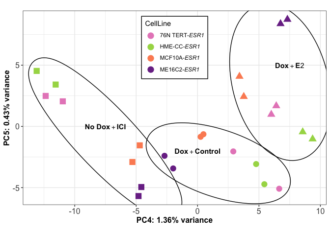

```r
percentVar_010 <- round(100 * attr(pcaData_010, "percentVar"), 2)

p1.1 <-  ggplot(pcaData_010,
                aes(x = PC4,
                    y = PC5,
                    shape = Treatment,
                    color = CellLine)) +
  geom_point(size = 4) +
  scale_color_manual(values = c("#e78ac3", "#a6d854", "#fc8d62","#7b3294")) +
  geom_mark_ellipse(aes(fill = NULL,
                        color = NULL,
                        #label = Treatment,
                        #label = rep(c("Dox_E2", "Dox_Control", "No_Dox_ICI"), 8),
                        ),
                    show.legend = FALSE,
                    con.type = "none",
                    label.buffer = unit(-20, "mm"),
                    label.fill = NULL
                    ) +
  xlab(paste0("PC4: ",percentVar_010[1],"% variance")) +
  ylab(paste0("PC5: ",percentVar_010[2],"% variance")) +
  theme_bw() +
  theme(plot.title = element_text(hjust = 0.5,
                                  size = 14,
                                  face = "bold"),
        axis.text = element_text(size = 12),
        axis.title = element_text(size = 12,
                                  face = "bold"),
        legend.position = "inside",
        legend.position.inside = c(0.5, 0.81),
        legend.box.spacing = unit(0, "mm"),
        legend.box = "horizontal",
        legend.box.margin = margin(0,0,0,0),
        legend.spacing.x = unit(0, "mm"),
        legend.key.spacing.y = unit(0, "mm"),
        legend.box.just = c("top"),
        legend.text = ggtext::element_markdown(),
        legend.background = element_rect(fill = NULL, color = "black")) +
  guides(shape="none") +
  annotate(geom = "text", x = -7.5, y = 0, label = "bold(`No Dox`+ICI)", parse = TRUE) +
  annotate(geom = "text", x = 7.5, y = 5, label = "bold(Dox+E2)", parse = TRUE) +
  annotate(geom = "text", x = 0., y = -2, label = "bold(Dox+Control)", parse = TRUE) +
  coord_fixed()

p1.1
```

#### 6. Get DGE from all comparisons for Control vs E2

In this case we define control as 1. Dox 2. H20 3. EtOH

```r
list_cells <- c("All", "MCF10A", "ME16C2", "HMECC", "76NTERT")
list_comparison <- c("Treatment_Dox_E2_vs_Dox_Control", "Treatment_No_Dox_ICI_vs_Dox_Control",              "Treatment_Dox_E2_vs_Dox_Control-Treatment_No_Dox_ICI_vs_Dox_Control")
```

#### 6.1 All Cell lines

```r
# get the data
data1 <- djj_getDGE(cellline = list_cells[1],
           comparison = list_comparison[1])

data1.1 <- djj_getDGE(cellline = list_cells[1],
           comparison = list_comparison[1])
```

#### 6.2 MCF10A-*ESR1*

```r
# get the data
data2 <- djj_getDGE(cellline = list_cells[2],
           comparison = list_comparison[1])
```

#### 6.3 ME16C2-*ESR1*

```r
# get the data
data3 <- djj_getDGE(cellline = list_cells[3],
           comparison = list_comparison[1])
```

#### 6.4 HME-CC-*ESR1*

```r
# get the data
data4 <- djj_getDGE(cellline = list_cells[4],
           comparison = list_comparison[1])
```

#### 6.5 76N TERT-*ESR1*-

```r
# get the data
data5 <- djj_getDGE(cellline = list_cells[5],
           comparison = list_comparison[1])
```

#### 6.7 Publicly avaialable data: MCF7

```r
#get MCF7 data only
dds_mcf7 <- dds_full[,1:6]
dds_mcf7$Treatment <- droplevels(dds_mcf7$Treatment)

#run DESeq
dge_mcf7 <- DESeq(dds_mcf7)

#the comparisions we can make
resultsNames(dge_mcf7)
```

```
## [1] "Intercept"               "Treatment_E2_vs_Control"
```

```r
# Get the DGE
res_mcf7 <- results(dge_mcf7, name = "Treatment_E2_vs_Control", alpha = 0.05)

#summary
summary(res_mcf7)
```

```
##
## out of 34200 with nonzero total read count
## adjusted p-value < 0.05
## LFC > 0 (up)       : 1829, 5.3%
## LFC < 0 (down)     : 1498, 4.4%
## outliers [1]       : 3, 0.0088%
## low counts [2]     : 19053, 56%
## (mean count < 12)
## [1] see 'cooksCutoff' argument of ?results
## [2] see 'independentFiltering' argument of ?results
```

```r
# Get the signficant genes
res_sig_mcf7 <- getSig(res_mcf7, padj = 0.05)
```

#### 6.8 Publicly avaialable data: T47D

```r
#get T47D data only
dds_t47d <- dds_full[,7:12]
dds_t47d$CellLine
```

```
## [1] "T47D" "T47D" "T47D" "T47D" "T47D" "T47D"
```

```r
dds_t47d$Treatment <- droplevels(dds_t47d$Treatment)

#run DESeq
dds_t47d <- DESeq(dds_t47d)

#the comparisions we can make
resultsNames(dds_t47d)
```

```
## [1] "Intercept"               "Treatment_E2_vs_Control"
```

```r
# Get the DGE
res_t47d <- results(dds_t47d, name = "Treatment_E2_vs_Control", alpha = 0.05)

#summary
summary(res_t47d)
```

```
##
## out of 29060 with nonzero total read count
## adjusted p-value < 0.05
## LFC > 0 (up)       : 1107, 3.8%
## LFC < 0 (down)     : 824, 2.8%
## outliers [1]       : 1, 0.0034%
## low counts [2]     : 15376, 53%
## (mean count < 19)
## [1] see 'cooksCutoff' argument of ?results
## [2] see 'independentFiltering' argument of ?results
```

```r
# Get the signficant genes
res_sig_t47d <- getSig(res_t47d, padj = 0.05)
```

### 7. Differentially expressed genes

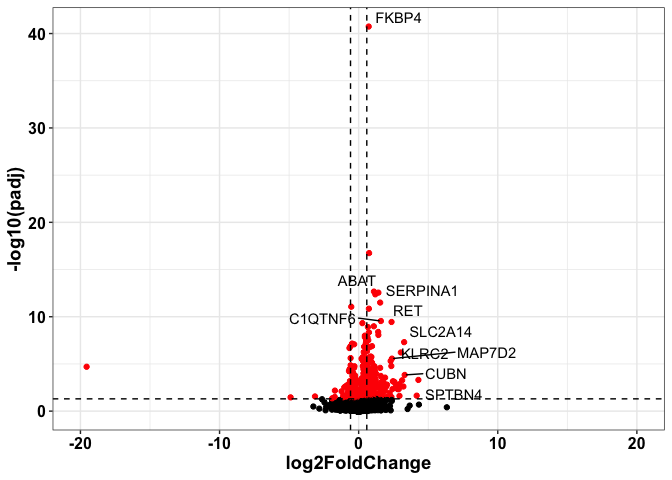

```r
resultObject <- data1$results

resultObject <- resultObject %>%
  as.data.frame() %>%
  drop_na(padj) %>%
  rownames_to_column("Ensembl_id") %>%
  mutate(Symbol = str_split(Ensembl_id, "_") %>% map_chr(2),
         Rank = log2FoldChange * - log10(pvalue),
         absLFC = abs(log2FoldChange)) %>%
  arrange(desc(Rank))
top10 <- resultObject[1:10,]

theme_prabin <- function(){
  theme(
      axis.text = element_text(face = "bold",
                               size = 12,
                               color = "black"),
      axis.title = element_text(face = "bold",
                                size = 14,
                                color = "black")
    )

}

volcano_v1 <- resultObject %>%
  ggplot2::ggplot(., aes(x = log2FoldChange,
                         y = -log10(padj),
                         label = ifelse(Rank %in% top10$Rank, Symbol, "")
                         )
                  ) +
  geom_point(aes(color = ifelse(padj < 0.05, "red", "black"))) +
  geom_text_repel(max.overlaps = Inf

                  ) +
  scale_color_identity() +
  geom_hline(yintercept = -log10(0.05),
             linetype = "dashed") +
  geom_vline(xintercept = -log2(1.5),
             linetype = "dashed") +
  geom_vline(xintercept = +log2(1.5),
             linetype = "dashed") +
  xlim(-20, 20) +
  theme_bw() +
  theme_prabin()


volcano_v1
```

#### 7.1 Venn Diagram

We will take the differentilly expressed genes Overlap between HBEC-ESR1, MCF7 and T47D.

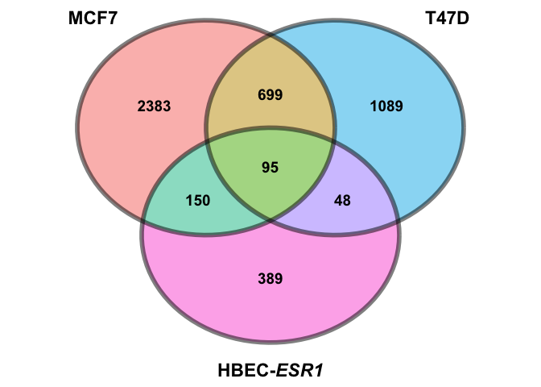

```r
#A list of the MCF7, T47D and HBEC-ESR1 diffentially expressed genes with padj < 0.5
dge_list <- list(res_sig_mcf7,
              res_sig_t47d,
              data1$Significant)
# we only need the names of the genes, not log2foldchange or other details
dge_names_list <- dge_list %>% map(., rownames)

#simplest way to plot with ggVennDiagram in this

# ggVennDiagram::ggVennDiagram(dge_names_list,
#                              show_intersect = FALSE,
#                              label = c("both"),
#                              category.names = c("MCF7", "T47D", "HBEC-*ESR1*")
#                              ) +
#   scale_fill_distiller(palette = "Set3")

#we confirmed that it works, now we will customise the ven diagram a bit more.

# https://venn.bio-spring.top/using-ggvenndiagram#comprehensive-customization-by-using-helper-functions
#create a dge list
dge_list <- list(res_sig_mcf7,
                       res_sig_t47d,
                       data1$Significant)
dge_names_list <- dge_list %>% map(., rownames)
#name the list
names(dge_names_list) <- c("bold('MCF7')", "bold('T47D')", "bold('HBEC-')*bolditalic('ESR1')")

#create a venn object
venn_1 <- Venn(dge_names_list)

data <- process_data(venn_1)

fill = c("#7fc97f",
                       "#beaed4",
                       "#fdc086",
                       "#ffff99",
                       "#386cb0",
                       "#f0027f",
                       "#bf5b17")
ven_2 <- ggplot() +
        #1. region count layer
        ## change mapping of color filling
        geom_polygon(aes(X, Y, fill = id, group = id),
                     alpha = 0.5,
                     data = venn_regionedge(data),
                     show.legend = FALSE) +
        #2. adjust edge size and color
        geom_path(aes(X, Y, group = id),
                  color = "black",
                  linewidth = 2,
                  alpha = 0.5,
                  data = venn_setedge(data),
                  show.legend = FALSE) +
        #3. show set label layer
        geom_text(aes(X, Y, label = name),
                  parse = TRUE,
                    nudge_y = -0.5,
               data = venn_setlabel(data),
               size = 6) +
        #4. region label layer
        geom_label(aes(X, Y, label = count),
                   data = venn_regionlabel(data),
                   alpha = 0, label.size = 0,
                   fontface = "bold",
                   size = 5) +
  theme_void() +
  scale_x_continuous(expand = expansion(mult = .2))

ven_2
```

### 8. Heatamp

We will use seriate

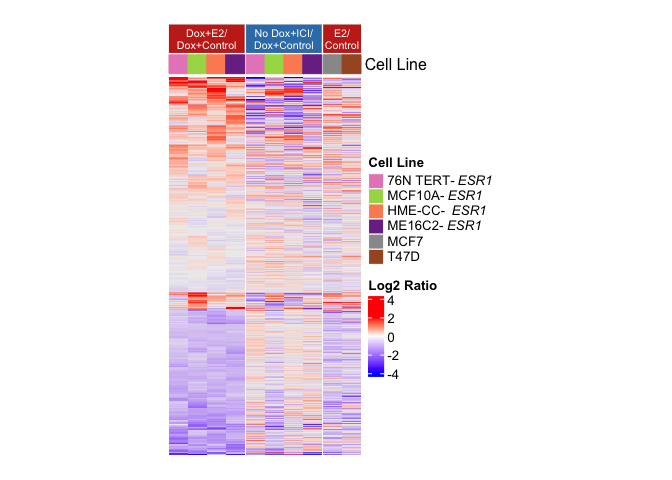

```r
#sort data1
sigData1 <- data1$Significant %>% as.data.frame() %>% arrange(desc(log2FoldChange)) %>% rownames()
label_name <- sigData1 %>% strsplit(., "_") %>% map_chr(2)
label_name <- list(label_name)


vsd_010<- vst(dds_010) %>%
  assay() %>%
  as.data.frame() %>%
  mutate(MCF10A_Dox_Control = rowMeans(select(.,
                                    starts_with('MCF10A_Dox_Control'))),
         MCF10A_Dox_E2 = rowMeans(select(.,
                                    starts_with('MCF10A_Dox_E2'))),
         MCF10A_No_Dox_ICI = rowMeans(select(.,
                                    starts_with('MCF10A_No_Dox_ICI'))),
         ME16C2_Dox_Control = rowMeans(select(.,
                                     starts_with('ME16C2_Dox_Control'))),
         ME16C2_Dox_E2 = rowMeans(select(.,
                                starts_with('ME16C2_Dox_E2'))),
         ME16C2_No_Dox_ICI = rowMeans(select(.,
                                    starts_with('ME16C2_No_Dox_ICI'))),
         HMECC_Dox_Control = rowMeans(select(.,
                                     starts_with('HMECC_Dox_Control'))),
         HMECC_Dox_E2 = rowMeans(select(.,
                                starts_with('HMECC_Dox_E2'))),
         HMECC_No_Dox_ICI = rowMeans(select(.,
                                    starts_with('HMECC_No_Dox_ICI'))),
         `76NTERT_Dox_Control` = rowMeans(select(.,
                                     starts_with('76NTERT_Dox_Control'))),
         `76NTERT_Dox_E2` = rowMeans(select(.,
                                starts_with('76NTERT_Dox_E2'))),
         `76NTERT_No_Dox_ICI` = rowMeans(select(.,
                                    starts_with('76NTERT_No_Dox_ICI'))),
         MCF7_Control = rowMeans(select(.,
                                    starts_with('MCF7_Control'))),
         MCF7_E2 = rowMeans(select(.,
                                    starts_with('MCF7_E2')))
) %>% select( -matches("_1|_2")) %>%
  rownames_to_column("Gene")

##### Plot Heatmap of the E2 change ##################
vsd_010_e2 <- vsd_010 %>%
  reframe(Gene = Gene,
          `76N TERT-ESR1` = `76NTERT_Dox_E2`/`76NTERT_Dox_Control`,
          `MCF10A-ESR1` = MCF10A_Dox_E2/MCF10A_Dox_Control,
          `HME-CC-ESR1` = HMECC_Dox_E2/HMECC_Dox_Control,
          `ME16C2-ESR1` = ME16C2_Dox_E2/ME16C2_Dox_Control
            ) %>%
  column_to_rownames(var = "Gene")


 vsd_010_e2 <- vsd_010_e2[sigData1,] %>%
  rownames_to_column("Gene") %>%
  mutate(Gene = str_split(Gene, "_") %>% map_chr(2)) %>%
  column_to_rownames(var = "Gene")

cell_col2 <- c("#e78ac3",
               "#a6d854",
               "#fc8d62",
               "#7b3294"
               )

names(cell_col2) <- colnames(vsd_010_e2)
ta <- HeatmapAnnotation(
        #first just a block to show all samples
        Log2 = anno_block(gp = gpar(fill = "#c82d1c", lex = 0.1),
                         labels = "Dox+E2/\nDox+Control",
                         labels_gp = gpar(col = "white", fontsize = 8, front = "bold"),
                         height = unit(7.5, "mm"),
                         show_name = FALSE),
        #second: add column names as color
        `Cell Line` = anno_simple(colnames(vsd_010_e2),
                          col = cell_col2),
        gap = unit(0.05, "cm"),
        show_annotation_name = FALSE
)

#make a legend separately
lgd_ta <- Legend(title = "Cell Line",
                 colnames(vsd_010_e2)[1:4],
                 legend_gp = gpar(fill = cell_col2),
                 labels = gt_render(colnames(vsd_010_e2) %>% str_replace("ESR1", "*ESR1*"))
                 )
#plot heatmap
h5 <- Heatmap(as.matrix(scale(vsd_010_e2)),
              top_annotation = ta,
              cluster_columns = FALSE,
              show_column_names = FALSE,
              show_column_dend = TRUE,
              cluster_rows = TRUE,
              show_row_dend = FALSE,
              show_row_names = FALSE,
              row_names_gp = gpar(fontsize = 6),
              width = unit(2, "cm"),
              height = unit(10, "cm"),
              show_heatmap_legend = FALSE
              )

#plot heatmap and legend
#ComplexHeatmap::draw(h5, annotation_legend_list = list(lgd_ta))

##### Plot Heatmap of the ICI change ##################

vsd_010_ici <- vsd_010 %>%
  reframe(Gene = Gene,
          `76N TERT-ESR1` = `76NTERT_No_Dox_ICI`/`76NTERT_Dox_Control`,
          `MCF10A-ESR1` = MCF10A_No_Dox_ICI/MCF10A_Dox_Control,
          `HME-CC-ESR1` = HMECC_No_Dox_ICI/HMECC_Dox_Control,
          `ME16C2-ESR1` = ME16C2_No_Dox_ICI/ME16C2_Dox_Control
            ) %>%
  column_to_rownames(var = "Gene")


 vsd_010_ici <- vsd_010_ici[sigData1,] %>%
  rownames_to_column("Gene") %>%
  mutate(Gene = str_split(Gene, "_") %>% map_chr(2)) %>%
  column_to_rownames(var = "Gene")

ta2 <- HeatmapAnnotation(
        #first just a block to show all samples
        Log2 = anno_block(gp = gpar(fill = "#377eb8", lex = 0.1),
                         labels = "No Dox+ICI/\nDox+Control",
                         labels_gp = gpar(col = "white", fontsize = 8, front = "bold"),
                         height = unit(7.5, "mm"),
                         show_name = FALSE),
        #second: add column names as color
        `Cell Line` = anno_simple(colnames(vsd_010_e2),
                          col = cell_col2),
        gap = unit(0.05, "cm"),
        show_annotation_name = FALSE
)

#make a legend separately
lgd_ta2 <- Legend(title = "Cell Line",
                 colnames(vsd_010_ici)[1:4],
                 legend_gp = gpar(fill = cell_col2),
                 labels = gt_render(colnames(vsd_010_ici) %>% str_replace("ESR1", "*ESR1*")))

h5_ici <- Heatmap(as.matrix(scale(vsd_010_ici)),
              top_annotation = ta2,
              cluster_columns = FALSE,
              show_column_names = FALSE,
              show_column_dend = TRUE,
              cluster_rows = TRUE,
              show_row_dend = FALSE,
              show_row_names = FALSE,
              row_names_gp = gpar(fontsize = 6),
              width = unit(2, "cm"),
              height = unit(10, "cm"),
              show_heatmap_legend = FALSE

)

#ComplexHeatmap::draw(h5_ici, annotation_legend_list = list(lgd_ta2))

#Get the MCF7 and T47D
dds_cancer <- dds_full[,1:12]
dds_cancer$Treatment <- droplevels(dds_cancer$Treatment)
vsd_cancer <- vst(dds_cancer)

vsd_cancer %<>%
  assay() %>%
  as.data.frame() %>%
  mutate(MCF7_Control = rowMeans(select(.,
                                    starts_with('MCF7_Control'))),
         MCF7_E2 = rowMeans(select(.,
                                    starts_with('MCF7_E2'))),
         T47D_Control = rowMeans(select(.,
                                    starts_with('T47D_Control'))),
         T47D_E2 = rowMeans(select(.,
                                    starts_with('T47D_E2')))
) %>% select( -matches("_1|_2")) %>%
  rownames_to_column("Gene") %>%
  reframe(Gene = Gene,
          MCF7 = MCF7_E2/MCF7_Control,
          T47D = T47D_E2/T47D_Control
            ) %>%
  column_to_rownames(var = "Gene")


vsd_cancer <- vsd_cancer[sigData1,] %>%
  rownames_to_column("Gene") %>%
  mutate(Gene = str_split(Gene, "_") %>% map_chr(2)) %>%
  column_to_rownames(var = "Gene")

cell_col3 <- c("#999999",
               "#a65628"
               )

names(cell_col3) <- colnames(vsd_cancer)

ta3 <- HeatmapAnnotation(
        #first just a block to show all samples
        Log2 = anno_block(gp = gpar(fill = "#c82d1c", lex = 0.1),
                         labels = "E2/\nControl",
                         labels_gp = gpar(col = "white", fontsize = 8, front = "bold"),
                         height = unit(7.5, "mm"),
                         show_name = FALSE),
        #second: add column names as color
        `Cell Line` = anno_simple(colnames(vsd_cancer),
                          col = cell_col3),
        gap = unit(0.05, "cm")
)

#make a legend separately
lgd_ta3 <- Legend(title = "Cell Line",
                 colnames(vsd_cancer)[1:2],
                 legend_gp = gpar(fill = cell_col3),
                 labels = gt_render(colnames(vsd_cancer) %>% str_replace("ESR1", "*ESR1*")))

h7 <- Heatmap(as.matrix(scale(vsd_cancer)),
              top_annotation = ta3,
              cluster_columns = FALSE,
              show_column_names = FALSE,
              show_column_dend = FALSE,
              show_row_dend = FALSE,
              cluster_rows = TRUE,
              show_row_names = FALSE,
              row_names_gp = gpar(fontsize = 6),
              width = unit(1, "cm"),
              height = unit(10, "cm"),
              show_heatmap_legend = FALSE
              )

#ComplexHeatmap::draw(h7, annotation_legend_list = list(lgd_ta3))


#create a legend for all three graphs
lgd_ta4 <- Legend(title = "Cell Line",
                 c(colnames(vsd_010_ici),colnames(vsd_cancer))[1:6],
                 legend_gp = gpar(fill = c(cell_col2, cell_col3)),
                 labels = gt_render(c(colnames(vsd_010_e2),colnames(vsd_cancer)) %>% str_replace("ESR1", "*ESR1*")))

lgd_ta5 <- Legend(title = "Log2 Ratio",
                  col_fun = colorRamp2(c(0, 2, 3),
                                       colors = c("blue", "white","red")),
                  at = c(0,1,2,3,4),
                  labels = c(-4, -2, 0, 2, 4)
                    )
ComplexHeatmap::draw(h5+h5_ici+h7, annotation_legend_list = list(lgd_ta4, lgd_ta5), ht_gap = unit(0.4, "mm"))
```

### 9. GSEA Analysis

#### 9.1 Prepare Data for GSEA

Generate log2TPM data with entrez geneID For HMEC Control/E2 and Control/ICI

```r
###10.1 Generate log2TPM data with entrez geneID For HMEC Control/E2

# We will used the merged columns

# obtain log2 counts data
vsd2_gsva_010_e2 <-  vsd_010 %>%
        reframe(Gene = Gene,
                MCF10A_E2 = MCF10A_Dox_E2/MCF10A_Dox_Control,
                `76NTERT_E2` = `76NTERT_Dox_E2`/`76NTERT_Dox_Control`,
                ME16C2_E2 = ME16C2_Dox_E2/ME16C2_Dox_Control,
                HMECC_E2 = HMECC_Dox_E2/HMECC_Dox_Control,
                MCF10A_ICI = MCF10A_No_Dox_ICI/MCF10A_Dox_Control,
          `76NTERT_ICI` = `76NTERT_No_Dox_ICI`/`76NTERT_Dox_Control`,
          ME16C2_ICI = ME16C2_No_Dox_ICI/ME16C2_Dox_Control,
          HMECC_ICI = HMECC_No_Dox_ICI/HMECC_Dox_Control
                  ) %>%
        mutate(ensembl_id = str_split(Gene, "\\.") %>% map_chr(1))

# First let's create a mapped data frame we can join to the gene expression values
mapped2_df_010_e2 <- mapIds(
                # Replace with annotation package for the organism relevant to your data
                org.Hs.eg.db,
                keys = vsd2_gsva_010_e2$ensembl_id,
                # Replace with the type of gene identifiers in your data
                keytype = "ENSEMBL",
                # Replace with the type of gene identifiers you would like to map to
                column = "ENTREZID",
                # This will keep only the first mapped value for each Ensembl ID
                multiVals = "first"
        ) %>%
        enframe() %>%
        `colnames<-`(c("Ensembl", "entrez_id")) %>%
        # If an Ensembl gene identifier doesn't map to a Entrez gene identifier,
        # drop that from the data frame
        dplyr::filter(!is.na(entrez_id)) %>%
        # Now let's join the rest of the expression data
        dplyr::inner_join(vsd2_gsva_010_e2, by = c("Ensembl" = "ensembl_id"))
#see how many duplicated gene ids are there
sum(duplicated(mapped2_df_010_e2$entrez_id))
```

```
## [1] 187
```

```r
# First let's determine the gene means
gene2_means_010_e2 <- rowMeans(mapped2_df_010_e2 %>% dplyr::select(-Ensembl, -entrez_id, -Gene))

# Let's add this as a column in our mapped_df
mapped2_df_010_e2 <- mapped2_df_010_e2 %>%
        # Add gene_means as a column called gene_means
        dplyr::mutate(gene2_means_010_e2) %>%
        # Reorder the columns so gene_means column is upfront
        dplyr::select(Ensembl, entrez_id, gene2_means_010_e2, dplyr::everything())

filtered2_mapped_df_010_e2 <- mapped2_df_010_e2 %>%
        # Sort so that the highest mean expression values are at the top
        dplyr::arrange(dplyr::desc(gene2_means_010_e2)) %>%
        # Filter out the duplicated rows using `dplyr::distinct()`
        dplyr::distinct(entrez_id, .keep_all = TRUE)

sum(duplicated(filtered2_mapped_df_010_e2$entrez_id))
```

```
## [1] 0
```

```r
# create rownames by Entrez gene id and remove Ensemble ID & SYMBOLS
filtered2_mapped_matrix_010_e2 <- filtered2_mapped_df_010_e2 %>%
        # GSVA can't the Ensembl IDs so we should drop this column as well as the means
        dplyr::select(-Ensembl, -gene2_means_010_e2, -Gene) %>%
        # We need to store our gene identifiers as row names
        tibble::column_to_rownames("entrez_id") %>%
        # Now we can convert our object into a matrix
        as.matrix()

expr2_010_e2 <- filtered2_mapped_df_010_e2 %>%
  select(-c("Ensembl","entrez_id","gene2_means_010_e2")) %>%
  mutate(NAME = str_split(Gene, "_") %>% map_chr(2),
         DESCRIPTION = rep("na")) %>%
  select(-Gene) %>%
  relocate(c("NAME", "DESCRIPTION"), .before = "MCF10A_E2")


# expr2_010_e2 %>% head %>% view
#
# if(!dir.exists("../GSEA")){
#   dir.create("../GSEA")
# }
# if(!file.exists("../GSEA/Hmec_e2_ici_expression.txt")){
#   write_tsv(expr2_010_e2,file = "../GSEA/Hmec_e2_ici_expression.txt")
# }
#
# Hmec_gene_ranks <- data1$Significant %>%
#   as.data.frame() %>%
#   rownames_to_column(var = "Gene") %>%
#    mutate(Gene = str_split(Gene, "_") %>% map_chr(2),
#           Rank = log2FoldChange * - log10(pvalue)) %>%
#   select(Gene, Rank) %>%
#   arrange(desc(Rank))
#
# if(!file.exists("../GSEA/Hmec_gene_ranks.rnk")){
#   write_tsv(Hmec_gene_ranks,file = "../GSEA/Hmec_gene_ranks.rnk")
# }
#
# phenotype_gsea <- list( a = c(ncol(expr2_010_e2)-1, 2, 1),
#                         b = paste("#", "Estrogen", "ICI"),
#                         c = rep(c(0,1), each = 4))
#
# if(!file.exists("../GSEA/Phen_Hmec_e2_ici_expression.cls")){
#   write_csv(phenotype_gsea,file = "../GSEA/Phen_Hmec_e2_ici_expression.cls")
# }
```

#### 9.2 Create a top-table plot like blitzGSEA

```r
### I did the GSEA analysis (not the pre-ranked) with phenotypes E2 and Dox.
### GSEA producess a report in an html file, in which all information is linked.
### From that we will the list of geneset enrichment.
### For each phenotype, there is 1 file. So we will read both

gsea_e2 <- read_tsv("./data/my_analysis.Gsea.1694117944567_e2/gsea_report_for_E2_1694117944567.tsv")
gsea_ctrl <- read_tsv("./data/my_analysis.Gsea.1694117944567_e2/gsea_report_for_Dox_1694117944567.tsv")

# According to GSEA,
# https://docs.gsea-msigdb.org/#GSEA/GSEA_User_Guide/#gsea-statistics
# The false discovery rate (FDR) is the estimated probability that a gene set with a given NES represents a false positive finding. For example, an FDR of 25% indicates that the result is likely to be valid 3 out of 4 times. The GSEA analysis report highlights enrichment gene sets with an FDR of less than 25% as those most likely to generate interesting hypotheses and drive further research, but provides analysis results for all analyzed gene sets. In general, given the lack of coherence in most expression datasets and the relatively small number of gene sets being analyzed, an FDR cutoff of 25% is appropriate. However, if you have a small number of samples and use gene_set permutation (rather than phenotype permutation) for your analysis, you are using a less stringent assessment of significance and would then want to use a more stringent FDR cutoff, such as 5%.
# So will collect gene sets with FDR 0.25 cut off.
#

for.blitz <- list(gsea_e2, gsea_ctrl)

# purr::map function is a bit tricky to figure out.
for.blitz <- for.blitz %>% map(., filter, `FDR q-val` < 0.25)
for.blitz %>% map(., dim)
```

```
## [[1]]
## [1]  8 12
##
## [[2]]
## [1]  1 12
```

```r
for.blitz %<>% bind_rows()
for.blitz
```

```
## # A tibble: 9 × 12
##   NAME        GS<br> follow link t…¹ `GS DETAILS`  SIZE     ES   NES `NOM p-val`
##   <chr>       <chr>                  <chr>        <dbl>  <dbl> <dbl>       <dbl>
## 1 HALLMARK_E… HALLMARK_ESTROGEN_RES… Details ...    200  0.765  1.58     0
## 2 HALLMARK_E… HALLMARK_ESTROGEN_RES… Details ...    200  0.698  1.48     0
## 3 HALLMARK_E… HALLMARK_E2F_TARGETS   Details ...    200  0.754  1.43     0.00404
## 4 HALLMARK_G… HALLMARK_G2M_CHECKPOI… Details ...    200  0.698  1.40     0.0207
## 5 HALLMARK_M… HALLMARK_MYC_TARGETS_… Details ...    200  0.564  1.37     0.0474
## 6 HALLMARK_O… HALLMARK_OXIDATIVE_PH… Details ...    200  0.488  1.36     0.0848
## 7 HALLMARK_S… HALLMARK_SPERMATOGENE… Details ...    135  0.539  1.33     0.0144
## 8 HALLMARK_D… HALLMARK_DNA_REPAIR    Details ...    150  0.489  1.32     0.0521
## 9 HALLMARK_T… HALLMARK_TGF_BETA_SIG… Details ...     54 -0.579 -1.66     0.00938
## # ℹ abbreviated name: ¹`GS<br> follow link to MSigDB`
## # ℹ 5 more variables: `FDR q-val` <dbl>, `FWER p-val` <dbl>,
## #   `RANK AT MAX` <dbl>, `LEADING EDGE` <chr>, ...12 <lgl>
```

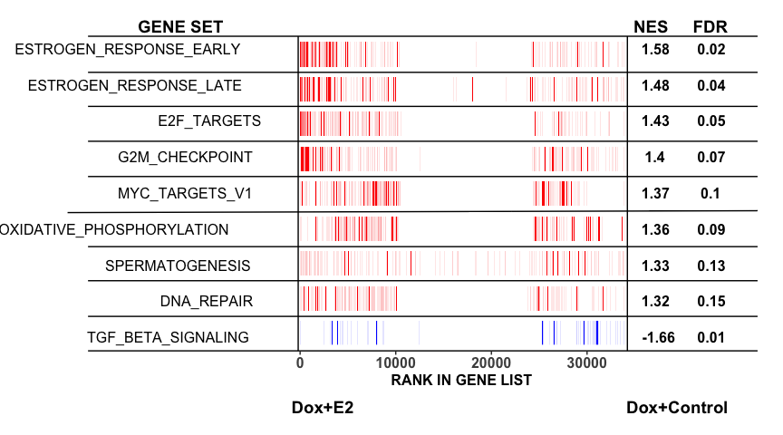

```r
# we have 8 gene set enriched and 1 negatively associated

### we need to get information on each genes on these gene sets.
### these are saved as separate files in the GSEA result folder.
### Helpflly names with the same geneset name.
### we will keep the genelist as a dataframe, and have all 9 as list of
### 9 dataframes.

for.blitz2 <- lapply(1:9, function(x){
  read_tsv(paste("data/my_analysis.Gsea.1694117944567_e2/", for.blitz$NAME[x], ".tsv", sep = "")) %>%
    select(`RANK IN GENE LIST`, `CORE ENRICHMENT`) %>%
    mutate(NAME = str_remove(for.blitz$NAME[x], "HALLMARK_"),
           NES = for.blitz$NES[x],
           stack = x,
           path_rank = x-0.5)
})

### We will create a top table plot like this.
#### https://github.com/MaayanLab/blitzgsea

# first take 1 gene-set a create a plot
a1 <- ggplot2::ggplot(for.blitz2[[9]],
                mapping = aes(x = `RANK IN GENE LIST`,
                              y = path_rank,
                              group = `NES`)) +
        geom_tile(fill = ifelse(for.blitz2[[9]]$NES>0, "red", "blue"),
                 alpha = 1,
                 width = 10) +
        theme_bw() +
        theme(panel.grid = element_blank(),
              panel.border = element_blank(),
              axis.text.y = element_blank(),
              axis.title.y = element_blank(),
              axis.ticks.y = element_blank(),
              axis.text.x = element_blank(),
              axis.title.x = element_blank(),
              axis.ticks.x = element_blank(),
              legend.position = "none"
              )
# in the preivous version I have kept the geom_col and colour
# in this version, I have used geom_tile and fill. I makes a little faded, which is great to show enrichment of the geneset to one phenotype.

### We will create a1 like plots for each gene-set and append them with cowplot.
### we will create the x-axis only to append to the bottom of the graphs

# make only the x-axis
a2 <- ggplot2::ggplot(for.blitz2[[1]],
                      mapping = aes(x = `RANK IN GENE LIST`,
                                    y = 0,
                                    color = ifelse(`NES` > 1, "red", "blue"))) +
        geom_col() +
        theme_bw() +
        theme(panel.grid = element_blank(),
              panel.border = element_blank(),
              axis.text.y = element_blank(),
              axis.title.y = element_blank(),
              axis.ticks.y = element_blank(),
              axis.text.x = element_text(size = 12, face = "bold"),
              axis.title.x = element_text(size = 12, face = "bold"),
              legend.position = "none"
        )

# this is how it will look in combination
#cowplot::plot_grid(a1,NULL, a2, ncol = 1, nrow = 3,align = "hv",rel_heights = c(1, -0.1, 0.1))


### We will make a function for plotting all data together
### When looped using purr::map function, this will give us a list of plots
### We will then append the plots and the x-axis will cowplot.

# the function is same as the code for plotting a1
plot_bars <- function(data){
        ggplot2::ggplot(data,
                        mapping = aes(x = `RANK IN GENE LIST`,
                                      y = path_rank,
                                      group = `NES`)) +
                geom_tile(fill = ifelse(data$NES>0, "red", "blue"),
                          alpha = 1,
                          width = 10) +
                theme_bw() +
                theme(panel.grid = element_blank(),
                      panel.border = element_blank(),
                      axis.text.y = element_blank(),
                      axis.title.y = element_blank(),
                      axis.ticks.y = element_blank(),
                      axis.text.x = element_blank(),
                      axis.title.x = element_blank(),
                      axis.ticks.x = element_blank(),
                      legend.position = "none"
                )
}

# make a list of plots
blitz.plots <- for.blitz2 %>% map(., plot_bars)
# the plot labels are the names of the gene sets or pathways.
# It may be more human readable to remove the "HALLMARK_"
# We will add labels after the plots are combined in cowplot
labels <- str_remove(for.blitz$NAME, "HALLMARK_")

### Combine the plots
### But making sure that there are NULL plots in between. This helps us remove
### spaces between our plots.
### Hence, we have total 19 rows of plots and 1 column.

cowd <- cowplot::plot_grid(blitz.plots[[1]],
                   NULL,
                   blitz.plots[[2]],
                   NULL,
                   blitz.plots[[3]],
                   NULL,
                   blitz.plots[[4]],
                   NULL,
                   blitz.plots[[5]],
                   NULL,
                   blitz.plots[[6]],
                   NULL,
                   blitz.plots[[7]],
                   NULL,
                   blitz.plots[[8]],
                   NULL,
                   blitz.plots[[9]],
                   NULL,
                   a2,
                   ncol = 1,
                   rnow = 19,
                   label_x = -1,
                   label_size = 12,
                   label_y = 0.8,
                   align = "hv",
                   axis = "l",
                   hjust = -1,
                   vjust = ,
                   rel_heights = c(rep(c(0.5,-0.1),  8), 0.5, -0.1, 0.5),
                   rel_widths = 0.5

                   )

### create margins for putting the labels.
### we would like to have both left and right margins and some top margins too.
cowd_p <- cowd + theme(plot.margin = unit(c(1,4,0,8), "cm"))

# y-axis positions for the labels.
y_pos <- seq(0.99,0.19, by = -0.09)

# the gene-sets phrases are unequal in length. there is no particular method to
# align them. Hence, we will check the position and adjust x positions accordingly.
cowd_p2 <- cowd_p + draw_plot_label(label = labels,
                                  x = c(-1,-0.95,-0.45, -0.6, -0.6, -1.05, -0.65, -0.43, -0.72),
                                  y = y_pos,
                                  size = 12,
                                  fontface = "plain"
                                        )
# On the right hand side, we will add normalised enrichment score for each gene set.
cowd_p3 <- cowd_p2 + draw_plot_label(label = round(for.blitz$NES, digits = 2),
                                     x = c(rep(0.95,3), 0.97, rep(0.95, 4), 0.945),
                                     y= y_pos,
                                     size = 12)
# On the right hand side, we will add normalised enrichment score for each gene set.
cowd_p4 <- cowd_p3 + draw_plot_label(label = round(for.blitz$`FDR q-val`, digits = 2),
                                     x = c(rep(1.1,4), 1.12, rep(1.1, 4)),
                                     y= y_pos,
                                     size = 12)
# On further right, we will ad the FDR value.
cowd_p5 <- cowd_p4 + draw_plot_label(c(" GENE SET", "", "NES", "FDR"),
                                     x = c(-0.5, 0, 0.92,1.08  ),
                                     y = 1.05,
                                     size = 14)
# now we will create rectangles to give the plots its own home
cowd_p6 <- cowd_p5 +
        annotate("segment", x = 1.3, xend = -0.5, y = 0.995, yend = 0.995) +
        annotate("segment", x = 1.3, xend = -0.5, y = 0.905, yend = 0.905) +
        annotate("segment", x = 1.3, xend = -0.5, y = 0.82, yend = 0.82) +
        annotate("segment", x = 1.3, xend = -0.5, y = 0.733, yend = 0.733) +
        annotate("segment", x = 1.3, xend = -0.5, y = 0.645, yend = 0.645) +
        annotate("segment", x = 1.3, xend = -0.555, y = 0.56, yend = 0.555) +
        annotate("segment", x = 1.3, xend = -0.5, y = 0.47, yend = 0.47) +
        annotate("segment", x = 1.3, xend = -0.5, y = 0.385, yend = 0.385) +
        annotate("segment", x = 1.3, xend = -0.5, y = 0.296, yend = 0.296) +
        annotate("segment", x = 1.3, xend = -0.5, y = 0.21, yend = 0.21)
# adding the phenotypes for each
cowd_p7 <- cowd_p6 + draw_plot_label(label = c("Dox+E2", "Dox+Control"),
                          x = c(-0.037, 0.81  ),
                          y = 0.1,
                          size = 14) +
        annotate("segment", x = 0.065, xend = 0.065, y = 0.21, yend = 0.995)+
        annotate("segment", x = 0.95, xend = 0.95, y = 0.21, yend = 0.995)

cowd_p7
```

## Additional

### 1. Plot a barplot

```r
vsd_010 <- dds_010 %>% vst()
```

```
## using 'avgTxLength' from assays(dds), correcting for library size
```

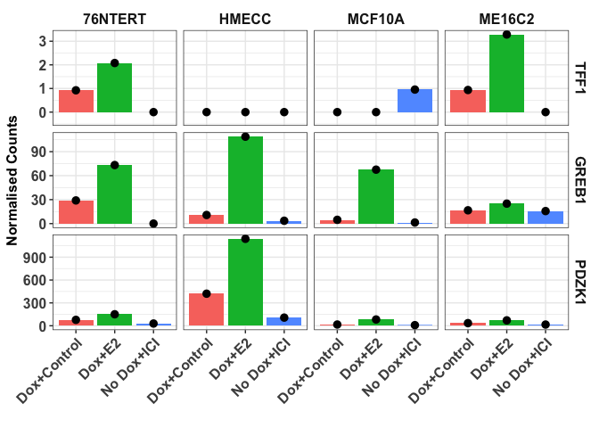

```r
x <- vsd_010 %>% assay() %>% as.data.frame %>% rownames_to_column(var = "Gene")

genelist <- list("RAD51",'BRCA1', "BRCA2", "TP53", "APOBEC3B")

#this is a re-usaable function to to plot individual genes in dotp and line plot
barplotGenes <- function(dataset = vsd_010, genelist = list()){
  x <- vsd_010 %>% assay() %>% as.data.frame %>% rownames_to_column(var = "Gene")
  genelist <- paste(genelist, "$", sep = "")
  bardata <- genelist %>% map(~x[str_detect(x$Gene, .),]) %>%
    bind_rows() %>% pivot_longer(cols = !Gene) %>%
    mutate(CellLine = str_split(name, "_") %>% map_chr(1),
           Treatment = case_when(str_detect(name, "E2") ~ "Dox_E2",
                                 str_detect(name, "No") ~ "No_Dox_ICI",
                                 str_detect(name, "Control") ~ "Dox_Control"),
           Gene_Name = str_split(Gene, "_") %>% map_chr(2),
           Replicate = reverse(name) %>% substr(start = 1, stop = 1)
    ) %>% mutate(Treatment = factor(Treatment, levels = c("Dox_Control", "Dox_E2", "No_Dox_ICI")))
  y = bardata %>% ggplot(., aes(x = Treatment,
                                y = value,
                                group = Replicate)) +
    geom_line() +
    geom_point() + facet_grid(Gene_Name ~ CellLine) +
    labs(x = "", y = "Log2Counts") +
    theme_bw() +
    theme(axis.text = element_text(angle = 90))
  return(y)

}

a <- barplotGenes(genelist = genelist)
genelist <- list("ESR1","AREG", "PDK4", "TGFA", "RSPO1")
genelist <- list("KRT8", "KRT18", "KRT19", "KRT14", "BMI1")
a <- barplotGenes(genelist = genelist)


# second barplot to plot genes
barplotGenes2 <- function(dataset = counts.sf_normalized, genelist = list()){
  x <- dataset %>% as.data.frame() %>% rownames_to_column(var = "Gene")
  bardata <- genelist %>% map(~x[str_detect(x$Gene, .),]) %>%
      bind_rows() %>% pivot_longer(cols = !Gene) %>%
      mutate(CellLine = str_split(name, "_") %>% map_chr(1),
             Treatment = case_when(str_detect(name, "E2") ~ "Dox+E2",
                                   str_detect(name, "No") ~ "No Dox+ICI",
                                   str_detect(name, "Control") ~ "Dox+Control"),
             Gene_Name = str_split(Gene, "_") %>% map_chr(2),
             Replicate = reverse(name) %>% substr(start = 1, stop = 1)
      ) %>% mutate(Treatment = factor(Treatment, levels = c("Dox+Control", "Dox+E2", "No Dox+ICI"))) %>%
    group_by(CellLine, Treatment, Gene_Name) %>% dplyr::summarise(Mean = mean(value), Sd = sd(value)) %>%
    mutate(Gene_Name = factor(Gene_Name, levels = substr(genelist, 1, nchar(genelist)-1)))

  y = bardata %>% ggplot(., aes(x = Treatment,
                                  y = Mean)) +
      geom_bar(aes(fill = Treatment),stat = "identity", position = position_dodge2()) +
      geom_pointrange(aes(ymin = Mean-Sd, ymax = Mean-Sd),position = position_dodge2(width = 0.5, padding = 0.5)) +
      facet_grid(Gene_Name ~ CellLine, scales = "free_y" ) +
      labs(x = "", y = "Normalised Counts") +
      theme_bw() +
      theme(axis.text = element_text(angle = 90),
            axis.text.x = element_text(hjust = 1, angle = 45)) +
    theme_pdm4014()
  return(y)

}


genelist <- list("TFF1$", "GREB1$", "PDZK1$")
barplotGenes2(genelist = genelist)
```

### 1.2 Save Processed Data for GEO Submission

In this case we will save the normalised counts data from RNA-Seq data generated here i.e. of the HBEC-*ESR1* not of the BC cell lines.

```r
 # write_tsv(as.data.frame(counts.sf_normalized), file = "../geo_submission_RNAseq//normalised_read_counts_all_samples.txt")
```